# Number generator

A simple AI able to generate handwritten-like numbers Author: Martin Prieto Aguilera

We are going to make use of the MNIST dataset of handwritten numbers. Here, we build an autoencoder that will construct a reduced representation of the dataset.

Then, we shall obtain the statistics for the endodings of each number (the mean vector and the covatiance matrix for each number encoding) and use such statistics to define a gaussian generator that will provide us with the encodings of other images that, if done properly, should resemble the encodings of "handwritten" number associated to those statistics.

Finally, we shall pass the codings generated by the gaussian process through a decoder (which we shall train alongside the encoder) in order to obtain the images of new "handwritten" number (of course, in reality, they would be computer generated, but they will imitate the way humans write them).

```python
#### ONLY IN COLAB
# Upgrade Tensorflow to version 2.0 (only in colab)
!pip install --upgrade tensorflow

from google.colab import drive
drive.mount('/content/drive')
```

```python
# import packages
import numpy as np
import tensorflow as tf
import matplotlib.pyplot as plt

import fetchers # for fetching data
import mpa_random # custom function to generate pseudorandom data
import pickle # for saving data
```

```python
# Load MNIST dataset
data_path = '../../data/MNIST_digits/' # local
# data_path = "drive/My Drive/TFM/MNIST_digits" # COLAB
X_train, X_test, t_train, t_test = fetchers.fetch_mnist_digit_data(data_path)
# Scale to [0,1]
X_train = (X_train / 255).astype(np.float32)
X_test = (X_test / 255).astype(np.float32)

print("X_train shape: ", X_train.shape)
print("t_train shape: ", t_train.shape)
print("X_test shape: ", X_test.shape)
print("t_test shape: ", t_test.shape)
```

```
X_train shape:  (60000, 28, 28, 1)
t_train shape:  (60000,)
X_test shape:  (10000, 28, 28, 1)
t_test shape:  (10000,)
```

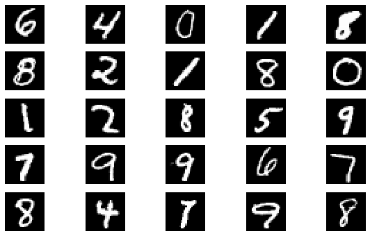

```python
# Show some of the data
nrows = 5
ncols = 5
selection = mpa_random.random_choice_first_dimension(X_train, sample_size=nrows*ncols)
fig, ax = plt.subplots(nrows=nrows, ncols=ncols, figsize=(10,6))
for i in range(nrows):
    for j in range(ncols):
        flat_index = i * ncols + j
        ax[i,j].imshow(selection[flat_index,:,:,0], cmap='gray')
        ax[i,j].axis('off')
```

## Dataset preprocessing

Since we got a small dataset, we can do a general preprocessing and store the modified dataset on memory for latter use. First, we shall create a noisy dataset. We'll perform a min-max scaling and flatten input images.

**Adding random noise**to the dataset is a way to build a more robust autoencoder, since it will make more difficult for it to simply memorize which images correspond to each number).

Although the best way to prevent a machine learning model from overfitting is simply to **make it simple** (this is, with a low capacity given the provided dataset). The simplier the model, the less patterns it can "memorize". THis way, we force it to learn the patterns that are truly useful for rebuilding the images later on.

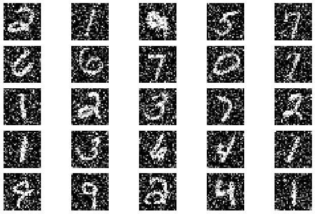

```python
# Add noise to the data. Training our model with noisy data will result in a more robust model.
noise_mu = 0 # noise mean
noise_std = 0.4 # noise std
white_noise = (noise_std * np.random.randn(*X_train.shape) + noise_mu).astype(np.float32)
X_train_noisy = (X_train + white_noise).clip(0,1)

# Show some observations from the noisy dataset
selection = mpa_random.random_choice_first_dimension(X_train_noisy, sample_size=nrows*ncols)
fig, ax = plt.subplots(nrows=nrows, ncols=ncols, figsize=(10,6))
for i in range(nrows):
    for j in range(ncols):
        flat_index = i * ncols + j
        ax[i,j].imshow(selection[flat_index,:,:,0], cmap='gray')
        ax[i,j].axis('off')

plt.tight_layout()
```

```python
# Flatten dataset
X_train_flatten = np.reshape(X_train, (X_train.shape[0], np.prod(X_train.shape[1:])))
X_test_flatten = np.reshape(X_test, (X_test.shape[0], np.prod(X_test.shape[1:])))

X_train_noisy_flatten = np.reshape(X_train_noisy, (X_train.shape[0], np.prod(X_train.shape[1:])))

print("X_train_flatten shape: ", X_train_flatten.shape)
print("X_test_flatten shape: ", X_test_flatten.shape)
```

```
X_train_flatten shape:  (60000, 784)
X_test_flatten shape:  (10000, 784)
```

## Model design

Here, we design the Model using Keras interface

We shall define the autoencoder with two parameters:

- The **decrese rate** which is the relationship between the number of neurons in layer *k* and layer *k+1*. A decrese rate of 2 means that each subsecuent layer has half the neurons that is predecessor.
- The **number of layers for encodig** which is simply the depth of the encoder.
- The decoder will be build symmetrically with respect to the encoder.

A part from the *call()* method (which will obtain the output of the whole model encoder-decoder) we shall implement a method specifically for encoding and a method specifically for decoding.

```python
class MNIST5Autoencoder(tf.keras.Model):
    """
    A flat autoencoder. This one will start by flattening out the input images. The coder and decoder will have simmetry,
    but will not share any weights.

    Each dense leyer will reduce the dimmensionality of the previous layer by a factor of 2.
    """
    def __init__(self, input_units, decrease_rate=2, n_layers_enc=1):
        """
        decrease_rate: The number of hidden units in a coding layer divided by the number of hidden units in the previous layer
        n_layers_enc: The number of layers used for encoding (default 1)
        """
        super(MNIST5Autoencoder, self).__init__()

        # Define the number of units per hidden layer in codder
        divisor = decrease_rate**np.arange(1, n_layers_enc + 1, 1)
        units = (input_units / divisor).astype(np.int)

        # ENCODER
        self.codding_layers = []
        # Build codding layers
        self.codding_layers.append(tf.keras.layers.Dense(units[0], input_shape=(input_units,), activation=tf.keras.activations.elu))
        for u in units[1:-1]:
            layer = tf.keras.layers.Dense(u, activation=tf.keras.activations.elu)
            self.codding_layers.append(layer)

        # Append last codding layer (it shall use linear activation)
        self.codding_layers.append(tf.keras.layers.Dense(units[-1],activation=None))


        # DECODER
        self.decodding_layers = []
        # Build decodding layers
        for u in units[-2::-1]:
            layer = tf.keras.layers.Dense(u,activation=tf.keras.activations.elu)
            self.decodding_layers.append(layer)

        # Append last decoding layer (it'll be the same size as the input, with sigmoid activation)
        self.decodding_layers.append(tf.keras.layers.Dense(input_units, activation=tf.keras.activations.sigmoid))


    def call(self, X):
        """
        Forwardprop function.
        X: input data. Should be min-max normalized, to match a range of [0,1]
        """

        # ENCODING
        # Forwardprop through the first hidden layer
        Y = self.codding_layers[0](X)
        for layer in self.codding_layers[1:]:
            Y = layer(Y)

        # DECODING
        for layer in self.decodding_layers:
            Y = layer(Y)

        return Y


    def encode(self, X):
        """
        Encodex X
        """
        Y = self.codding_layers[0](X)
        for layer in self.codding_layers[1:]:
            Y = layer(Y)

        return Y

    def decode(self, X):
        """
        Decodes X
        """
        Y = self.decodding_layers[0](X)
        for layer in self.decodding_layers[1:]:
            Y = layer(Y)

        return Y
```

# Define training parameters and procedure

```python
batch_size = 20
n_epochs = 100

# For dataset shuffleing
buffer_size = 100

# Define the optimizer
eta = 0.01
momentum = 0.9
optimizer = tf.keras.optimizers.SGD(learning_rate=eta, momentum=momentum)

# Define model
model = MNIST5Autoencoder(X_train_flatten.shape[1], decrease_rate=2, n_layers_enc=4)

# Define dataset
dataset = tf.data.Dataset.from_tensor_slices((X_train_noisy_flatten, X_train_flatten))
dataset = dataset.shuffle(buffer_size=buffer_size)
dataset = dataset.batch(batch_size=batch_size)

#### TRAINING LOOP ####
for epoch in range(n_epochs):
    for batch in dataset:
        X_noisy = batch[0]
        X_clean = batch[1]
        # Perform a training step
        with tf.GradientTape() as tape:
            Y = model(X_noisy) # Forwardprop to obtain model output
            errors = tf.keras.losses.MSE(y_true=X_clean, y_pred=Y)
            loss = tf.math.reduce_mean(errors)

          # Compute gradients
        grads = tape.gradient(loss, model.variables)
        # Apply gradients through optimizer
        optimizer.apply_gradients(zip(grads, model.variables))
    # Compute loss over test
    Y_test_flatten = model(X_test_flatten)
    errors = tf.keras.losses.MSE(y_true=X_test_flatten, y_pred=Y_test_flatten)
    loss = tf.reduce_mean(errors)
    # print("Epoch {}, loss: {}".format(epoch, loss))
```

```python
# Save model weights for latter use
model.save_weights(data_path + '/generative_autoencoder.keras')
```

```python
#### RESTORE MODEL WEIGHTS (WHEN WE TRAINED THE MODEL IN THE PAST AND DON'T WANNA DO THAT AGAIN)
model = MNIST5Autoencoder(X_train_flatten.shape[1], decrease_rate=2, n_layers_enc=4)
#### A dummy call to the model is necessary to step over a bug ####
dummy_call = model(np.zeros([1,np.prod(X_train.shape[1:3])], dtype=np.float32))
# The weights variables need to be initialized in order for the load operation to work. One can load them by calling the model on some dummy data.
model.load_weights('generative_autoencoder.keras')
```

```python
# Define an auxiliary function that shall aid us latter on
def random_choice_first_dimension(X, sample_size):
    """
    Selects several elements randomly in a 4-D tensor where the first dimension indexes the different elements.
    This is, if X is a vector of 3-D tensors, selects randomly a sample_size of such tensors.
    """
    selected_indices = np.random.randint(0, high=X.shape[0], size=sample_size)
    selector = np.zeros(X.shape[0], dtype=np.bool)
    selector[selected_indices] = True
    return X[selector,:,:,:]
```